# IE 425 Homework 1

Utku Atay,Sercan Demirkilic

03 05 2020

## Question 1

Firstly, we add the library “tree” and determine the set.seed values to 425. After that, we read the values from “heart.csv” data.When we check the attributes by str function, we see that it contains 13 attributes and 1 output variable. We change some attributes to categorical variable by using “as.factor” such as sex,cp,fbs,rectecg,exang,thal and target.

```r
library(tree)
set.seed(425)

heart = read.csv("C:/Users/user/Desktop/heart.csv")
str(heart)
```

```
## 'data.frame':    303 obs. of  14 variables:
##  $ age     : int  63 37 41 56 57 57 56 44 52 57 ...
##  $ sex     : int  1 1 0 1 0 1 0 1 1 1 ...
##  $ cp      : int  3 2 1 1 0 0 1 1 2 2 ...
##  $ trestbps: int  145 130 130 120 120 140 140 120 172 150 ...
##  $ chol    : int  233 250 204 236 354 192 294 263 199 168 ...
##  $ fbs     : int  1 0 0 0 0 0 0 0 1 0 ...
##  $ restecg : int  0 1 0 1 1 1 0 1 1 1 ...
##  $ thalach : int  150 187 172 178 163 148 153 173 162 174 ...
##  $ exang   : int  0 0 0 0 1 0 0 0 0 0 ...
##  $ oldpeak : num  2.3 3.5 1.4 0.8 0.6 0.4 1.3 0 0.5 1.6 ...
##  $ slope   : int  0 0 2 2 2 1 1 2 2 2 ...
##  $ ca      : int  0 0 0 0 0 0 0 0 0 0 ...
##  $ thal    : int  1 2 2 2 2 1 2 3 3 2 ...
##  $ target  : int  1 1 1 1 1 1 1 1 1 1 ...
```

```r
heart$sex = as.factor(heart$sex)
heart$cp = as.factor(heart$cp)
heart$fbs = as.factor(heart$fbs)
heart$restecg = as.factor(heart$restecg)
heart$exang = as.factor(heart$exang)
heart$thal = as.factor(heart$thal)
heart$target = as.factor(heart$target)

table(heart$target)
```

```
##
##   0   1
## 138 165
```

### Part A

A tree is built by using function tree. The output variable is target and data is come from heart variable. We plot the tree and text the decisions.In the tree, there 20 terminal nodes.

```r
tree.heart = tree(target~. , data = heart)
tree.heart
```

```
## node), split, n, deviance, yval, (yprob)
##       * denotes terminal node
##
##  1) root 303 417.600 1 ( 0.45545 0.54455 )
##    2) thal: 0,1,3 137 155.700 0 ( 0.74453 0.25547 )
##      4) cp: 0 91  63.020 0 ( 0.89011 0.10989 )
##        8) oldpeak < 0.55 22  28.840 0 ( 0.63636 0.36364 )
##         16) chol < 237.5 12  16.300 1 ( 0.41667 0.58333 ) *
##         17) chol > 237.5 10   6.502 0 ( 0.90000 0.10000 ) *
##        9) oldpeak > 0.55 69  18.110 0 ( 0.97101 0.02899 )
##         18) thal: 0,3 58   0.000 0 ( 1.00000 0.00000 ) *
##         19) thal: 1 11  10.430 0 ( 0.81818 0.18182 ) *
##      5) cp: 1,2,3 46  63.420 1 ( 0.45652 0.54348 )
##       10) ca < 0.5 28  33.500 1 ( 0.28571 0.71429 )
##         20) oldpeak < 0.1 7   0.000 1 ( 0.00000 1.00000 ) *
##         21) oldpeak > 0.1 21  27.910 1 ( 0.38095 0.61905 ) *
##       11) ca > 0.5 18  21.270 0 ( 0.72222 0.27778 )
##         22) restecg: 0 7   0.000 0 ( 1.00000 0.00000 ) *
##         23) restecg: 1 11  15.160 0 ( 0.54545 0.45455 )
##           46) thalach < 141.5 5   0.000 0 ( 1.00000 0.00000 ) *
##           47) thalach > 141.5 6   5.407 1 ( 0.16667 0.83333 ) *
##    3) thal: 2 166 173.600 1 ( 0.21687 0.78313 )
##      6) ca < 0.5 114  76.720 1 ( 0.10526 0.89474 )
##       12) thalach < 160.5 53  54.130 1 ( 0.20755 0.79245 )
##         24) oldpeak < 1.7 46  39.230 1 ( 0.15217 0.84783 )
##           48) age < 58.5 27   8.554 1 ( 0.03704 0.96296 ) *
##           49) age > 58.5 19  23.700 1 ( 0.31579 0.68421 )
##             98) cp: 0,3 9  12.370 0 ( 0.55556 0.44444 ) *
##             99) cp: 1,2 10   6.502 1 ( 0.10000 0.90000 ) *
##         25) oldpeak > 1.7 7   9.561 0 ( 0.57143 0.42857 ) *
##       13) thalach > 160.5 61  10.210 1 ( 0.01639 0.98361 )
##         26) chol < 323 56   0.000 1 ( 0.00000 1.00000 ) *
##         27) chol > 323 5   5.004 1 ( 0.20000 0.80000 ) *
##      7) ca > 0.5 52  71.780 1 ( 0.46154 0.53846 )
##       14) cp: 0 20  16.910 0 ( 0.85000 0.15000 )
##         28) sex: 0 6   8.318 1 ( 0.50000 0.50000 ) *
##         29) sex: 1 14   0.000 0 ( 1.00000 0.00000 ) *
##       15) cp: 1,2,3 32  33.620 1 ( 0.21875 0.78125 )
##         30) age < 55.5 16   7.481 1 ( 0.06250 0.93750 ) *
##         31) age > 55.5 16  21.170 1 ( 0.37500 0.62500 )
##           62) age < 65.5 9  11.460 0 ( 0.66667 0.33333 ) *
##           63) age > 65.5 7   0.000 1 ( 0.00000 1.00000 ) *
```

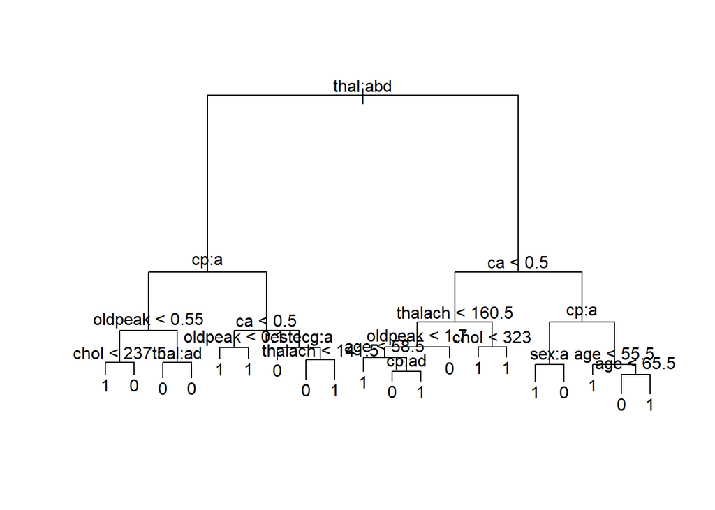

```r
plot(tree.heart)
text(tree.heart)
```

We try to find best tree by using 5-Fold Cross Validation method. In cv heart variable, we can see that deviance is minimum when node size is equal to 6.

```r
cv.heart = cv.tree (tree.heart, K=5)
cv.heart
```

```
## $size
##  [1] 20 19 18 17 16 14 12 11  9  8  7  6  5  4  3  2  1
##
## $dev
##  [1] 532.5262 404.3503 386.0619 380.2536 384.3712 384.3712 375.2547 348.7064
##  [9] 348.8812 349.0309 349.0309 320.5175 345.5104 351.1430 352.6293 378.1310
## [17] 421.5852
##
## $k
##  [1]      -Inf  4.831916  5.201240  5.592903  6.038900  6.159615  7.340988
##  [8]  7.674233  7.931793  8.590597  8.647857 12.382770 16.077469 21.250382
## [15] 25.107282 29.260715 88.324476
##
## $method
## [1] "deviance"
##
## attr(,"class")
## [1] "prune"         "tree.sequence"
```

To get the best tree (minimum deviance), we prune the tree to 6 nodes.The residual mean deviance is 0.8001 and the error rate is 0.1749.

```r
heart.cut = prune.tree(tree.heart, best=6)
heart.cut
```

```
## node), split, n, deviance, yval, (yprob)
##       * denotes terminal node
##
##  1) root 303 417.60 1 ( 0.45545 0.54455 )
##    2) thal: 0,1,3 137 155.70 0 ( 0.74453 0.25547 )
##      4) cp: 0 91  63.02 0 ( 0.89011 0.10989 )
##        8) oldpeak < 0.55 22  28.84 0 ( 0.63636 0.36364 ) *
##        9) oldpeak > 0.55 69  18.11 0 ( 0.97101 0.02899 ) *
##      5) cp: 1,2,3 46  63.42 1 ( 0.45652 0.54348 ) *
##    3) thal: 2 166 173.60 1 ( 0.21687 0.78313 )
##      6) ca < 0.5 114  76.72 1 ( 0.10526 0.89474 ) *
##      7) ca > 0.5 52  71.78 1 ( 0.46154 0.53846 )
##       14) cp: 0 20  16.91 0 ( 0.85000 0.15000 ) *
##       15) cp: 1,2,3 32  33.62 1 ( 0.21875 0.78125 ) *
```

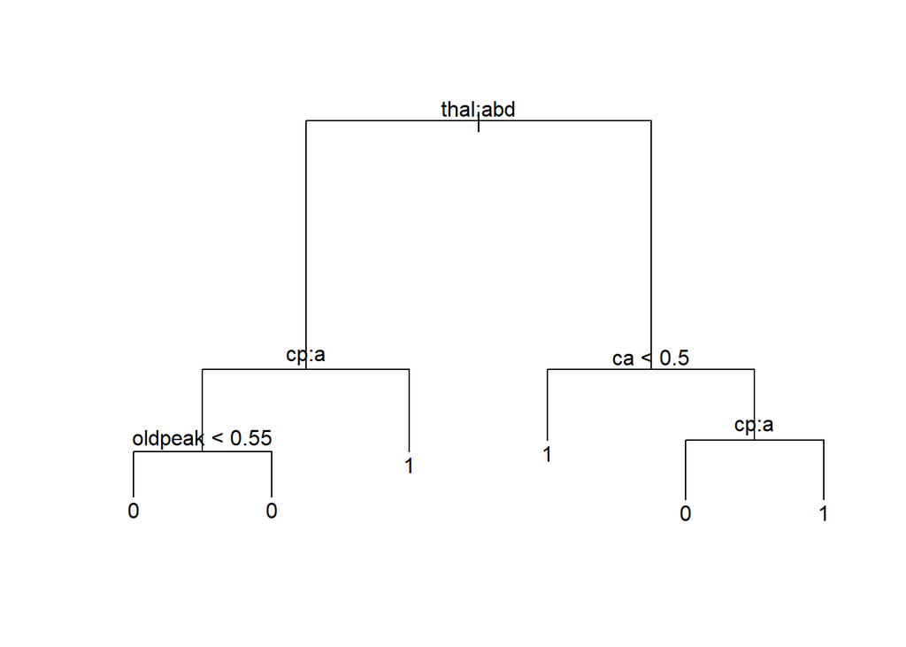

```r
plot(heart.cut)
text(heart.cut)
```

```r
summary(heart.cut)
```

```
##
## Classification tree:
## snip.tree(tree = tree.heart, nodes = c(8L, 15L, 9L, 14L, 5L,
## 6L))
## Variables actually used in tree construction:
## [1] "thal"    "cp"      "oldpeak" "ca"
## Number of terminal nodes:  6
## Residual mean deviance:  0.8001 = 237.6 / 297
## Misclassification error rate: 0.1749 = 53 / 303
```

### Part B

```r
pred.heart = predict(heart.cut ,type = "class")
table(heart$target, pred.heart)
```

```
##    pred.heart
##       0   1
##   0  98  40
##   1  13 152
```

### Part C

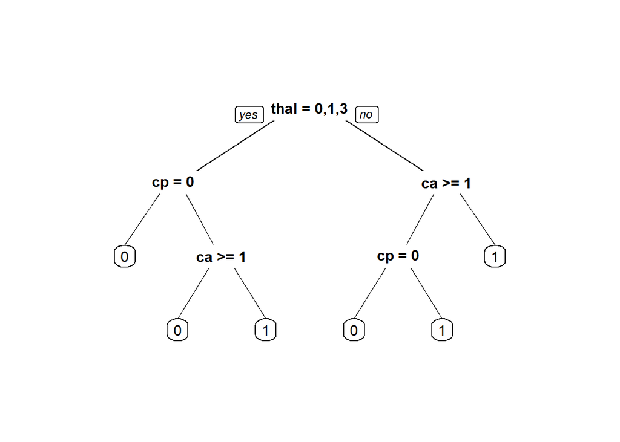

```r
library(rpart)
library(rpart.plot)

set.seed(425)
rpart.heart = rpart(target~., method="class", data=heart)
prp(rpart.heart)
```

```r
summary(rpart.heart)
```

```
## Call:
## rpart(formula = target ~ ., data = heart, method = "class")
##   n= 303
##
##           CP nsplit rel error    xerror       xstd
## 1 0.48550725      0 1.0000000 1.0000000 0.06281757
## 2 0.05072464      1 0.5144928 0.6086957 0.05646266
## 3 0.04347826      3 0.4130435 0.5144928 0.05342847
## 4 0.01000000      5 0.3260870 0.4710145 0.05177794
##
## Variable importance
##     thal       cp  thalach    exang  oldpeak       ca      sex trestbps
##       27       22       12       10        9        8        6        2
##    slope      age
##        2        1
##
## Node number 1: 303 observations,    complexity param=0.4855072
##   predicted class=1  expected loss=0.4554455  P(node) =1
##     class counts:   138   165
##    probabilities: 0.455 0.545
##   left son=2 (137 obs) right son=3 (166 obs)
##   Primary splits:
##       thal    splits as  LLRL,      improve=41.79470, (0 missing)
##       cp      splits as  LRRR,      improve=40.01976, (0 missing)
##       ca      < 0.5   to the right, improve=32.58051, (0 missing)
##       exang   splits as  RL,        improve=28.67017, (0 missing)
##       thalach < 147.5 to the left,  improve=26.32128, (0 missing)
##   Surrogate splits:
##       thalach < 150.5 to the left,  agree=0.683, adj=0.299, (0 split)
##       cp      splits as  LRRR,      agree=0.677, adj=0.285, (0 split)
##       exang   splits as  RL,        agree=0.670, adj=0.270, (0 split)
##       sex     splits as  RL,        agree=0.657, adj=0.241, (0 split)
##       oldpeak < 0.95  to the right, agree=0.657, adj=0.241, (0 split)
##
## Node number 2: 137 observations,    complexity param=0.04347826
##   predicted class=0  expected loss=0.2554745  P(node) =0.4521452
##     class counts:   102    35
##    probabilities: 0.745 0.255
##   left son=4 (91 obs) right son=5 (46 obs)
##   Primary splits:
```

[output cut: 78 more lines]

```
##
## Node number 11: 28 observations
##   predicted class=1  expected loss=0.2857143  P(node) =0.09240924
##     class counts:     8    20
##    probabilities: 0.286 0.714
##
## Node number 12: 20 observations
##   predicted class=0  expected loss=0.15  P(node) =0.0660066
##     class counts:    17     3
##    probabilities: 0.850 0.150
##
## Node number 13: 32 observations
##   predicted class=1  expected loss=0.21875  P(node) =0.1056106
##     class counts:     7    25
##    probabilities: 0.219 0.781
```

### Part D

```r
pred.heart2 = predict(rpart.heart, type = "class")
table(heart$target, pred.heart2)
```

```
##    pred.heart2
##       0   1
##   0 111  27
##   1  18 147
```

## Quesiton 2

### Part A

Firstly, we have to manipulate our data to use it efficiently. Our data has a country variable which as more than 100 attributes. However, the R programming language does not let us use that many factors. So that we converted that column to binary country variables whether the country is true or not. For that, we created more than 100 country variables and change them to factors. After that, we removed some variables from our data because of unnecessary usage. country: We created binary variables for each country country-year: We removed because data also has country and year variables. gdp_for_Year: Our data includes both GDP per capita and population so this variable is unnecessary. suicides no: We are trying to estimate the suicide rate per 100 thousand population. So, using this variable might be weird because the suicide rate can be found without estimation by using population and suicide numbers. Then, we changed a variable into factors. The number of year variable represents a factor or level instead of a number value. So that we gave different factor for each year. Additionally, we changed the name of some countries in order to get rid of the spaces between the words. We changed them into dots.

```r
library(tree)
library(dummies)
library(fastDummies)

suicide_rate = read.csv("C:/Users/user/Desktop/suicide-rate.csv")
summary(suicide_rate)
```

```
##         country           year          sex                 age
##  Austria    :  382   Min.   :1985   female:13910   15-24 years:4642
##  Iceland    :  382   1st Qu.:1995   male  :13910   25-34 years:4642
##  Mauritius  :  382   Median :2002                  35-54 years:4642
##  Netherlands:  382   Mean   :2001                  5-14 years :4610
##  Argentina  :  372   3rd Qu.:2008                  55-74 years:4642
##  Belgium    :  372   Max.   :2016                  75+ years  :4642
##  (Other)    :25548
##   suicides_no        population       suicides.100k.pop      country.year
##  Min.   :    0.0   Min.   :     278   Min.   :  0.00    Albania1987:   12
##  1st Qu.:    3.0   1st Qu.:   97498   1st Qu.:  0.92    Albania1988:   12
##  Median :   25.0   Median :  430150   Median :  5.99    Albania1989:   12
##  Mean   :  242.6   Mean   : 1844794   Mean   : 12.82    Albania1992:   12
##  3rd Qu.:  131.0   3rd Qu.: 1486143   3rd Qu.: 16.62    Albania1993:   12
##  Max.   :22338.0   Max.   :43805214   Max.   :224.97    Albania1994:   12
##                                                         (Other)    :27748
##           gdp_for_year.... gdp_per_capita....           generation
##  1,002,219,052,968:   12   Min.   :   251     Boomers        :4990
##  1,011,797,457,139:   12   1st Qu.:  3447     G.I. Generation:2744
##  1,016,418,229    :   12   Median :  9372     Generation X   :6408
##  1,018,847,043,277:   12   Mean   : 16866     Generation Z   :1470
##  1,022,191,296    :   12   3rd Qu.: 24874     Millenials     :5844
##  1,023,196,003,075:   12   Max.   :126352     Silent         :6364
##  (Other)          :27748
```

```r
str(suicide_rate)
```

```
## 'data.frame':    27820 obs. of  11 variables:
##  $ country           : Factor w/ 101 levels "Albania","Antigua and Barbuda",..: 1 1 1 1 1 1 1 1 1 1 ...
##  $ year              : int  1987 1987 1987 1987 1987 1987 1987 1987 1987 1987 ...
##  $ sex               : Factor w/ 2 levels "female","male": 2 2 1 2 2 1 1 1 2 1 ...
##  $ age               : Factor w/ 6 levels "15-24 years",..: 1 3 1 6 2 6 3 2 5 4 ...
##  $ suicides_no       : int  21 16 14 1 9 1 6 4 1 0 ...
##  $ population        : int  312900 308000 289700 21800 274300 35600 278800 257200 137500 311000 ...
##  $ suicides.100k.pop : num  6.71 5.19 4.83 4.59 3.28 2.81 2.15 1.56 0.73 0 ...
##  $ country.year      : Factor w/ 2321 levels "Albania1987",..: 1 1 1 1 1 1 1 1 1 1 ...
##  $ gdp_for_year....  : Factor w/ 2321 levels "1,002,219,052,968",..: 727 727 727 727 727 727 727 727 727 727 ...
##  $ gdp_per_capita....: int  796 796 796 796 796 796 796 796 796 796 ...
##  $ generation        : Factor w/ 6 levels "Boomers","G.I. Generation",..: 3 6 3 2 1 2 6 1 2 3 ...
```

```r
suicide_rate<- dummy_cols(suicide_rate, select_column = "country")
str(suicide_rate)
```

```
## 'data.frame':    27820 obs. of  112 variables:
##  $ country                             : Factor w/ 101 levels "Albania","Antigua and Barbuda",..: 1 1 1 1 1 1 1 1 1 1 ...
##  $ year                                : int  1987 1987 1987 1987 1987 1987 1987 1987 1987 1987 ...
##  $ sex                                 : Factor w/ 2 levels "female","male": 2 2 1 2 2 1 1 1 2 1 ...
##  $ age                                 : Factor w/ 6 levels "15-24 years",..: 1 3 1 6 2 6 3 2 5 4 ...
##  $ suicides_no                         : int  21 16 14 1 9 1 6 4 1 0 ...
##  $ population                          : int  312900 308000 289700 21800 274300 35600 278800 257200 137500 311000 ...
##  $ suicides.100k.pop                   : num  6.71 5.19 4.83 4.59 3.28 2.81 2.15 1.56 0.73 0 ...
##  $ country.year                        : Factor w/ 2321 levels "Albania1987",..: 1 1 1 1 1 1 1 1 1 1 ...
##  $ gdp_for_year....                    : Factor w/ 2321 levels "1,002,219,052,968",..: 727 727 727 727 727 727 727 727 727 727 ...
##  $ gdp_per_capita....                  : int  796 796 796 796 796 796 796 796 796 796 ...
##  $ generation                          : Factor w/ 6 levels "Boomers","G.I. Generation",..: 3 6 3 2 1 2 6 1 2 3 ...
##  $ country_Albania                     : int  1 1 1 1 1 1 1 1 1 1 ...
##  $ country_Antigua and Barbuda         : int  0 0 0 0 0 0 0 0 0 0 ...
##  $ country_Argentina                   : int  0 0 0 0 0 0 0 0 0 0 ...
```

[output cut: 86 more lines]

```r
names(suicide_rate)<-make.names(names(suicide_rate),unique = TRUE)

cols <- c(12:112)
suicide_rate[cols] <- lapply(suicide_rate[cols], as.factor)
str(suicide_rate)
```

```
## 'data.frame':    27820 obs. of  112 variables:
##  $ country                             : Factor w/ 101 levels "Albania","Antigua and Barbuda",..: 1 1 1 1 1 1 1 1 1 1 ...
##  $ year                                : int  1987 1987 1987 1987 1987 1987 1987 1987 1987 1987 ...
##  $ sex                                 : Factor w/ 2 levels "female","male": 2 2 1 2 2 1 1 1 2 1 ...
##  $ age                                 : Factor w/ 6 levels "15-24 years",..: 1 3 1 6 2 6 3 2 5 4 ...
##  $ suicides_no                         : int  21 16 14 1 9 1 6 4 1 0 ...
##  $ population                          : int  312900 308000 289700 21800 274300 35600 278800 257200 137500 311000 ...
##  $ suicides.100k.pop                   : num  6.71 5.19 4.83 4.59 3.28 2.81 2.15 1.56 0.73 0 ...
##  $ country.year                        : Factor w/ 2321 levels "Albania1987",..: 1 1 1 1 1 1 1 1 1 1 ...
##  $ gdp_for_year....                    : Factor w/ 2321 levels "1,002,219,052,968",..: 727 727 727 727 727 727 727 727 727 727 ...
##  $ gdp_per_capita....                  : int  796 796 796 796 796 796 796 796 796 796 ...
##  $ generation                          : Factor w/ 6 levels "Boomers","G.I. Generation",..: 3 6 3 2 1 2 6 1 2 3 ...
##  $ country_Albania                     : Factor w/ 2 levels "0","1": 2 2 2 2 2 2 2 2 2 2 ...
##  $ country_Antigua.and.Barbuda         : Factor w/ 2 levels "0","1": 1 1 1 1 1 1 1 1 1 1 ...
##  $ country_Argentina                   : Factor w/ 2 levels "0","1": 1 1 1 1 1 1 1 1 1 1 ...
```

[output cut: 86 more lines]

```r
suicide_rate = suicide_rate[,-c(1,5,8,9)]
suicide_rate$year = as.factor(suicide_rate$year)
str(suicide_rate)
```

```
## 'data.frame':    27820 obs. of  108 variables:
##  $ year                                : Factor w/ 32 levels "1985","1986",..: 3 3 3 3 3 3 3 3 3 3 ...
##  $ sex                                 : Factor w/ 2 levels "female","male": 2 2 1 2 2 1 1 1 2 1 ...
##  $ age                                 : Factor w/ 6 levels "15-24 years",..: 1 3 1 6 2 6 3 2 5 4 ...
##  $ population                          : int  312900 308000 289700 21800 274300 35600 278800 257200 137500 311000 ...
##  $ suicides.100k.pop                   : num  6.71 5.19 4.83 4.59 3.28 2.81 2.15 1.56 0.73 0 ...
##  $ gdp_per_capita....                  : int  796 796 796 796 796 796 796 796 796 796 ...
##  $ generation                          : Factor w/ 6 levels "Boomers","G.I. Generation",..: 3 6 3 2 1 2 6 1 2 3 ...
##  $ country_Albania                     : Factor w/ 2 levels "0","1": 2 2 2 2 2 2 2 2 2 2 ...
##  $ country_Antigua.and.Barbuda         : Factor w/ 2 levels "0","1": 1 1 1 1 1 1 1 1 1 1 ...
##  $ country_Argentina                   : Factor w/ 2 levels "0","1": 1 1 1 1 1 1 1 1 1 1 ...
##  $ country_Armenia                     : Factor w/ 2 levels "0","1": 1 1 1 1 1 1 1 1 1 1 ...
##  $ country_Aruba                       : Factor w/ 2 levels "0","1": 1 1 1 1 1 1 1 1 1 1 ...
##  $ country_Australia                   : Factor w/ 2 levels "0","1": 1 1 1 1 1 1 1 1 1 1 ...
##  $ country_Austria                     : Factor w/ 2 levels "0","1": 1 1 1 1 1 1 1 1 1 1 ...
```

[output cut: 86 more lines]

```r
set.seed(492)
train= sample(1: nrow(suicide_rate), nrow(suicide_rate)*0.7)
suicide_train = suicide_rate[train,]
suicide_test = suicide_rate[-train,]
```

### Part B

Firstly we have created a regression tree for the train data set. Then, we applied our tree to our test data and predicted the suicide rate. After that, we find the Root Mean Square Error(RMSE) for our basic tree. However, this tree does not involve mincut or minsize. So that we created a function to calculate the RMSE values for different values of mincut or minsize. In other words, we are creating a different tree in every loop and assigning the RMSE value to an array. After that, we will be choosing the one with the smallest Root Mean Square Error. Since the RMSE values and trees are not changing in small differences of mincut or minsize we have more than one minimum value. Our best tree includes 15 terminal nodes with 176.9 residual mean deviance.

```r
suicide_tree = tree(suicides.100k.pop~. , data = suicide_train)
summary(suicide_tree)
```

```
##
## Regression tree:
## tree(formula = suicides.100k.pop ~ ., data = suicide_train)
## Variables actually used in tree construction:
##  [1] "sex"                        "age"
##  [3] "country_Lithuania"          "country_Russian.Federation"
##  [5] "country_Belarus"            "country_Kazakhstan"
##  [7] "country_Latvia"             "country_Ukraine"
##  [9] "population"                 "country_Slovenia"
## [11] "country_Hungary"            "country_Republic.of.Korea"
## Number of terminal nodes:  15
## Residual mean deviance:  176.9 = 3442000 / 19460
## Distribution of residuals:
##    Min. 1st Qu.  Median    Mean 3rd Qu.    Max.
## -89.900  -5.455  -1.582   0.000   3.036 182.900
```

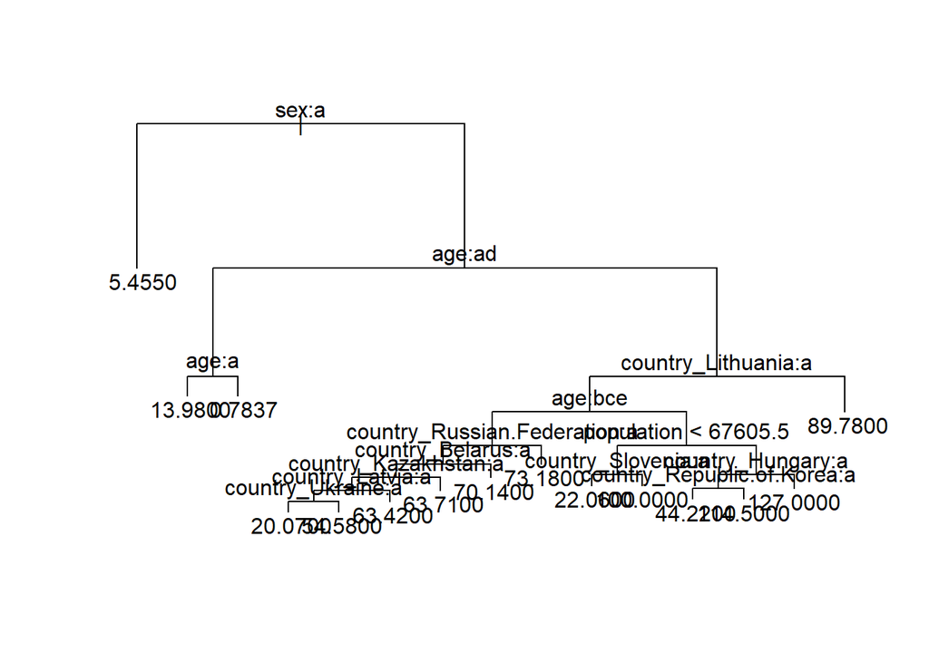

```r
plot(suicide_tree)
text(suicide_tree)
```

```r
suicide_tree
```

```
## node), split, n, deviance, yval
##       * denotes terminal node
##
##   1) root 19474 6934000  12.8600
##     2) sex: female 9726  538400   5.4550 *
##     3) sex: male 9748 5331000  20.2500
##       6) age: 15-24 years,5-14 years 3247  343900   7.3690
##        12) age: 15-24 years 1620  200300  13.9800 *
##        13) age: 5-14 years 1627    2207   0.7837 *
##       7) age: 25-34 years,35-54 years,55-74 years,75+ years 6501 4180000  26.6800
##        14) country_Lithuania: 0 6437 3890000  26.0500
##          28) age: 25-34 years,35-54 years,55-74 years 4833 1673000  22.4400
##            56) country_Russian.Federation: 0 4781 1514000  21.8900
##             112) country_Belarus: 0 4738 1400000  21.4500
##               224) country_Kazakhstan: 0 4685 1291000  20.9700
##                 448) country_Latvia: 0 4641 1191000  20.5700
##                   896) country_Ukraine: 0 4574 1099000  20.0700 *
##                   897) country_Ukraine: 1 67   13310  54.5800 *
##                 449) country_Latvia: 1 44   20280  63.4200 *
##               225) country_Kazakhstan: 1 53   13000  63.7100 *
##             113) country_Belarus: 1 43   13500  70.1400 *
##            57) country_Russian.Federation: 1 52   23050  73.1800 *
##          29) age: 75+ years 1604 1965000  36.9200
##            58) population < 67605.5 688  688800  23.6500
##             116) country_Slovenia: 0 674  601000  22.0600 *
##             117) country_Slovenia: 1 14    4529 100.0000 *
##            59) population > 67605.5 916 1064000  46.9000
##             118) country_Hungary: 0 900  938700  45.4700
##               236) country_Republic.of.Korea: 0 884  804700  44.2200 *
##               237) country_Republic.of.Korea: 1 16   56440 114.5000 *
##             119) country_Hungary: 1 16   20260 127.0000 *
##        15) country_Lithuania: 1 64   32120  89.7800 *
```

```r
pred_suicide=predict(suicide_tree, newdata= suicide_test)
RMSE = sqrt(mean((pred_suicide - suicide_test[,"suicides.100k.pop"])^2))
RMSE
```

```
## [1] 13.55887
```

```r
bestvalue <- function (train, test){
  parameters <- matrix(30,30, data = 99999)
  for(i in 10:30){
    for(j in 1:(i/2)) {

      suicide_tree = tree(suicides.100k.pop~. , data = train , mincut = j , minsize =  i )
      pred_suicide= predict(suicide_tree, newdata= test)
      parameters[i,j] = sqrt(mean((pred_suicide - test[,"suicides.100k.pop"])^2))
    }
  }
  return (which(parameters == min(parameters), arr.ind =TRUE))
}
bestvalue(suicide_train, suicide_test)
```

```
##        row col
##   [1,]  10   1
##   [2,]  11   1
##   [3,]  12   1
##   [4,]  13   1
##   [5,]  14   1
##   [6,]  15   1
##   [7,]  16   1
##   [8,]  17   1
##   [9,]  18   1
##  [10,]  19   1
##  [11,]  20   1
##  [12,]  21   1
##  [13,]  22   1
##  [14,]  23   1
```

[output cut: 190 more lines]

### Part C

Our regression tree shows that sex, age, and population are mainly the most important variables in making predictions. Additionally, some countries such as Belarus, Latvia, and Ukraine, have some significant effect on the suicide rate. If we want to compare the variables we might use the r-part function and see the variable importance. According to the R-Part function summary, our most important variables are age sex and generation.

```r
summary(suicide_tree)
```

```
##
## Regression tree:
## tree(formula = suicides.100k.pop ~ ., data = suicide_train)
## Variables actually used in tree construction:
##  [1] "sex"                        "age"
##  [3] "country_Lithuania"          "country_Russian.Federation"
##  [5] "country_Belarus"            "country_Kazakhstan"
##  [7] "country_Latvia"             "country_Ukraine"
##  [9] "population"                 "country_Slovenia"
## [11] "country_Hungary"            "country_Republic.of.Korea"
## Number of terminal nodes:  15
## Residual mean deviance:  176.9 = 3442000 / 19460
## Distribution of residuals:
##    Min. 1st Qu.  Median    Mean 3rd Qu.    Max.
## -89.900  -5.455  -1.582   0.000   3.036 182.900
```

### Part D

In order to apply 10-fold cross-validation, we used our main manipulated data set. Firstly we applied a regression tree and then used cv.tree function on our tree. By looking at our output we will be choosing the tree with the smallest deviation. So that we chose size=13 as our best tree. Then we used pürüne.tree function with K=13. By doing that we cut our tree as 13 nodes.

Additionally, we applied the R-part function. By looking output, we chose the node number with smaller CP and deviation. Our node number is again found as 13 similar to cv.tree.

```r
set.seed(492)
suicide_tree2 = tree (suicides.100k.pop ~. , data =suicide_rate)
cv.suicide_rate = cv.tree(suicide_tree2, K=10)
cv.suicide_rate
```

```
## $size
##  [1] 13 12 11 10  9  8  7  6  5  4  3  2  1
##
## $dev
##  [1]  5325454  5504664  5504664  5909522  5952742  6108391  6335802  6363571
##  [9]  6895292  6905455  7294604  8473491 10005032
##
## $k
##  [1]      -Inf  102651.7  105384.6  144017.9  152651.9  171208.7  189137.2
##  [8]  207404.6  285153.8  303736.4  391779.8 1179494.5 1533003.3
##
## $method
## [1] "deviance"
##
## attr(,"class")
## [1] "prune"         "tree.sequence"
```

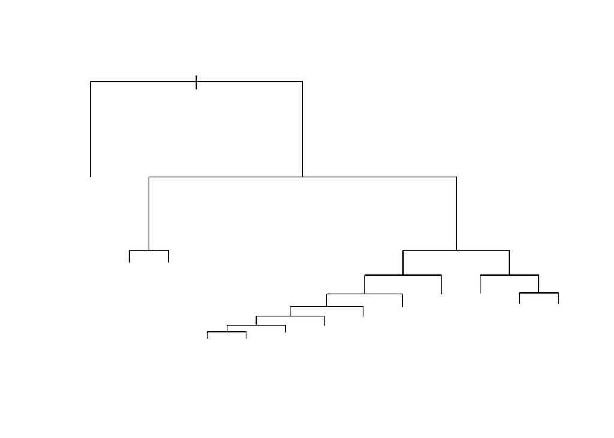

```r
suicide_rate.cut = prune.tree(suicide_tree2, best=13)
plot(suicide_rate.cut)
```

```r
suicide_rate.cut
```

```
## node), split, n, deviance, yval
##       * denotes terminal node
##
##   1) root 27820 10000000  12.8200
##     2) sex: female 13910   753200   5.3930 *
##     3) sex: male 13910  7716000  20.2400
##       6) age: 15-24 years,5-14 years 4626   470200   7.1940
##        12) age: 15-24 years 2321   278200  13.5700 *
##        13) age: 5-14 years 2305     2896   0.7778 *
##       7) age: 25-34 years,35-54 years,55-74 years,75+ years 9284  6066000  26.7400
##        14) age: 25-34 years,35-54 years,55-74 years 6963  2734000  22.9900
##          28) country_Lithuania: 0 6897  2391000  22.3400
##            56) country_Russian.Federation: 0 6816  2149000  21.7500
##             112) country_Belarus: 0 6753  1974000  21.2900
##               224) country_Kazakhstan: 0 6675  1812000  20.7900
##                 448) country_Latvia: 0 6612  1681000  20.4000
##                   896) country_Ukraine: 0 6528  1562000  19.9500 *
##                   897) country_Ukraine: 1 84    16750  55.1400 *
##                 449) country_Latvia: 1 63    26110  61.4900 *
##               225) country_Kazakhstan: 1 78    17480  64.0100 *
##             113) country_Belarus: 1 63    22730  70.7400 *
##            57) country_Russian.Federation: 1 81    34190  72.6500 *
##          29) country_Lithuania: 1 66    39810  90.5100 *
##        15) age: 75+ years 2321  2940000  37.9900
##          30) population < 17448 570   550000  18.5600 *
##          31) population > 17448 1751  2105000  44.3200
##            62) country_Hungary: 0 1725  1905000  43.1000 *
##            63) country_Hungary: 1 26    28730 124.9000 *
```

```r
summary(suicide_rate.cut)
```

```
##
## Regression tree:
## tree(formula = suicides.100k.pop ~ ., data = suicide_rate)
## Variables actually used in tree construction:
##  [1] "sex"                        "age"
##  [3] "country_Lithuania"          "country_Russian.Federation"
##  [5] "country_Belarus"            "country_Kazakhstan"
##  [7] "country_Latvia"             "country_Ukraine"
##  [9] "population"                 "country_Hungary"
## Number of terminal nodes:  13
## Residual mean deviance:  188.3 = 5236000 / 27810
## Distribution of residuals:
##    Min. 1st Qu.  Median    Mean 3rd Qu.    Max.
## -49.580  -5.393  -1.543   0.000   3.104 206.400
```

```r
rpart.suicide= rpart(suicides.100k.pop ~., data=suicide_rate )
rpart.suicide
```

```
## n= 27820
##
## node), split, n, deviance, yval
##       * denotes terminal node
##
##   1) root 27820 10002010.00  12.8161000
##     2) sex=female 13910   753238.80   5.3928660 *
##     3) sex=male 13910  7715771.00  20.2393300
##       6) age=15-24 years,5-14 years 4626   470209.80   7.1941760
##        12) age=5-14 years 2305     2896.20   0.7778308 *
##        13) age=15-24 years 2321   278176.40  13.5662900 *
##       7) age=25-34 years,35-54 years,55-74 years,75+ years 9284  6066066.00  26.7394200
##        14) age=25-34 years,35-54 years,55-74 years 6963  2734423.00  22.9888900
##          28) country_Lithuania=0 6897  2390877.00  22.3428000
##            56) country_Russian.Federation=0 6816  2149285.00  21.7450000
##             112) country_Belarus=0 6753  1973904.00  21.2879000
##               224) country_Kazakhstan=0 6675  1812402.00  20.7887000
##                 448) country_Latvia=0 6612  1680906.00  20.4008400
##                   896) country_Ukraine=0 6528  1561500.00  19.9538900 *
##                   897) country_Ukraine=1 84    16754.04  55.1358300 *
##                 449) country_Latvia=1 63    26111.58  61.4947600 *
##               225) country_Kazakhstan=1 78    17483.57  64.0085900 *
##             113) country_Belarus=1 63    22729.62  70.7414300 *
##            57) country_Russian.Federation=1 81    34187.61  72.6466700 *
##          29) country_Lithuania=1 66    39808.75  90.5051500 *
##        15) age=75+ years 2321  2939864.00  37.9910200
##          30) population< 17448 570   550048.50  18.5639300 *
##          31) population>=17448 1751  2104662.00  44.3150800
##            62) country_Hungary=0 1725  1904724.00  43.1011000 *
##            63) country_Hungary=1 26    28728.89 124.8581000 *
```

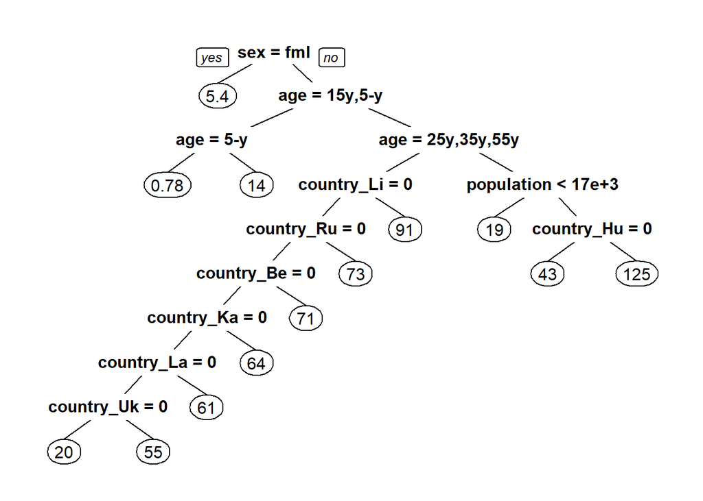

```r
prp(rpart.suicide)
```

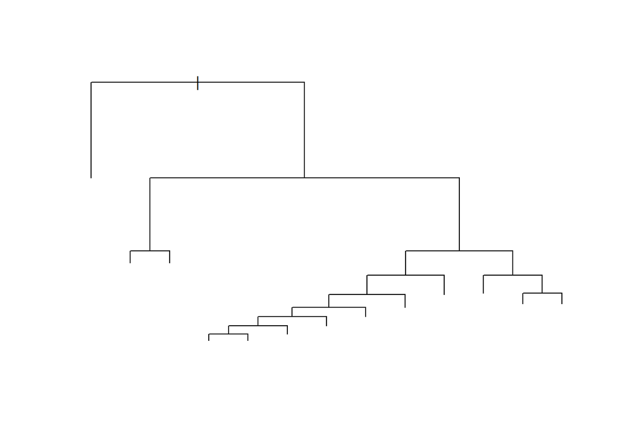

```r
plot(rpart.suicide)
```

```r
summary(rpart.suicide)
```

```
## Call:
## rpart(formula = suicides.100k.pop ~ ., data = suicide_rate)
##   n= 27820
##
##            CP nsplit rel error    xerror       xstd
## 1  0.15326948      0 1.0000000 1.0001007 0.02256610
## 2  0.11792572      1 0.8467305 0.8468380 0.01954639
## 3  0.03917009      2 0.7288048 0.7288956 0.01726930
## 4  0.03036753      3 0.6896347 0.6898279 0.01530508
## 5  0.02850965      4 0.6592672 0.6741810 0.01520619
## 6  0.02073629      5 0.6307575 0.6381930 0.01458946
## 7  0.01890991      6 0.6100212 0.6239090 0.01438013
## 8  0.01711743      7 0.5911113 0.5985410 0.01427604
## 9  0.01526212      8 0.5739939 0.5894985 0.01398241
## 10 0.01439889      9 0.5587318 0.5765200 0.01381220
## 11 0.01053634     10 0.5443329 0.5508383 0.01326254
## 12 0.01026311     11 0.5337966 0.5409645 0.01315790
## 13 0.01000000     12 0.5235334 0.5314304 0.01305528
##
## Variable importance
##                        age                        sex
##                         30                         26
##                 generation                 population
##                         16                          6
##          country_Lithuania country_Russian.Federation
##                          5                          4
##            country_Hungary            country_Belarus
##                          3                          3
##         country_Kazakhstan             country_Latvia
##                          2                          2
##            country_Ukraine
##                          2
##
## Node number 1: 27820 observations,    complexity param=0.1532695
##   mean=12.8161, MSE=359.526
##   left son=2 (13910 obs) right son=3 (13910 obs)
##   Primary splits:
##       sex                        splits as  LR,     improve=0.15326950, (0 missing)
##       age                        splits as  LRRLRR, improve=0.08910110, (0 missing)
##       generation                 splits as  RRLLLR, improve=0.08262781, (0 missing)
```

[output cut: 152 more lines]

```
##   Primary splits:
##       country_Ukraine   splits as  LR,          improve=0.06106929, (0 missing)
##       country_Hungary   splits as  LR,          improve=0.05656503, (0 missing)
##       country_Estonia   splits as  LR,          improve=0.04301606, (0 missing)
##       population        < 20465.5 to the left,  improve=0.03773471, (0 missing)
##       country_Sri.Lanka splits as  LR,          improve=0.03548494, (0 missing)
##
## Node number 449: 63 observations
##   mean=61.49476, MSE=414.4696
##
## Node number 896: 6528 observations
##   mean=19.95389, MSE=239.2004
##
## Node number 897: 84 observations
##   mean=55.13583, MSE=199.4528
```